# MA Fitness

Rutuja Gupte

2023-09-21

- this fits a spline to y=OD versus x=time, and then finds the maximum slope

```r
spline.slope<-function(x, y, n=101, eps=1e-5, span=0.2){
  max(nderiv(loess(log(y) ~ x, degree=1, span=span), seq(min(x), max(x), length=n)), na.rm=TRUE)
}
```

- used by the function above to get a local (linear) slope around a point

```r
nderiv <- function(fit, x, eps=1e-5){
  (predict(fit, x + eps) - predict(fit, x - eps))/(2 * eps)}
```

Import Statements

```r
library(dplyr)
library(stringr)
library(tidyverse)
library(lme4)
```

```r
# lib vioplot for violin plot
library(vioplot)
```

- this fits a spline to y=OD versus x=time, and then finds the time-stamp for maximum slope

## Needs updating

```r
spline.time<-function(x, y, n=101, eps=1e-5, span=0.2){
  which.max(nderiv(loess(log(y) ~ x, degree=1, span=span), seq(min(x), max(x), length=n)))
}
```

- this fits a linear regression model and extracts the slope

```r
well.lm.slope <- function(x, y){
  lm(y ~ x)$coefficients[2]
}
```

- this fits a linear regression model and extracts the sum of squared residuals

```r
well.lm.sse <- function(x, y){
  sum((summary(lm(y~x))$residuals)^2)
}
```

Load all files and setup variables

```r
l <- list.files()

# read all data into a list of data frames
dfs <- lapply(l[endsWith(l, '.csv')], function(r){
  d <- read.csv(r)

  assay.name <- str_replace(str_replace(r, 'Ref', 'Rutuja'), '.csv', '.txt')
  assay.data <- read.delim(assay.name)
  # Change time column to 0, 0.25, 0.5, ...
  assay.data$Time<-seq(from=0.25,by=0.25,length.out=nrow(assay.data))
  # calculate slopes
  d$slope <- sapply(c(1:nrow(d)), function(r){
    spline.slope(assay.data$Time, assay.data[,which(names(assay.data)==d$well[r])])
  })

  d$initial <- sapply(c(1:nrow(d)), function(r){
    mean(assay.data[,which(names(assay.data)==d$well[r])][1:4])
  })

  d$final <- sapply(c(1:nrow(d)), function(r){
    temp <- assay.data[,which(names(assay.data)==d$well[r])]
    temp <- temp[!is.na(temp)]
     n <- length(temp)
    mean(assay.data[,which(names(assay.data)==d$well[r])][n-3:n])
  })

  d$date <- mdy(str_replace(str_replace(r, 'Ref ', ''), '.csv', ' 2023'))
  return(d)
})

# merge the list of data frames
d <- dfs %>% reduce(bind_rows)

dates.1 <- seq(mdy(04062023), mdy(04102023), 1)
dates.2 <- seq(mdy(04282023), mdy(05052023), 1)
dates.2 <- c(dates.2, mdy(11022023))
ancestors <- c('H1', 'H2', 'H3', 'D1', 'D2', 'D3')
# these are all the haploid ancestors including the diploids that are supposed to be diploids
ancestors.haploid <- c('H1', 'H2', 'H3', 'D2', 'D3')
# these are haploids that were intended to be haploids
anc.hap.og <- c('H1', 'H2', 'H3')
# these are haploids that were intended to be diploids
anc.hap.fake <- c('D2', 'D3')
# this is the only actual diploid control that was diploid
ancestors.diploid <- c('D1')
# this MA line started out as a haploid but ended up as a diploid
fake.haploids <- c(81)
# these MA lines started out as diploids but ended up as haploids
fake.diploids <- c(20, 28, 48, 52, 54, 84, 100)
```

Adding additional information for categorization. Excluding MA lines that changed ploidy. Excluding batch 1 due to lack of diploid controls.

```r
d$batch[d$date %in% dates.1] <- 1
d$batch[d$date %in% dates.2] <- 2
d$label <- d$treatment
d$label[d$treatment == 'Blank'] <- '0'
d$label[d$treatment == 'H1'] <- '101'
d$label[d$treatment == 'D1'] <- '102'
d$label[d$treatment == 'H2'] <- '103'
d$label[d$treatment == 'D2'] <- '104'
d$label[d$treatment == 'H3'] <- '105'
d$label[d$treatment == 'D3'] <- '106'
d$label[d$treatment == 'C1'] <- '107'
d$label[d$treatment == 'C3'] <- '109'
d$label <- as.numeric(d$label)

d <- d %>% mutate(category = case_when(label == 0 ~ 'Blank',
                              label > 100 & treatment %in% ancestors.haploid ~ 'Ctrl.H',
                              label > 100 & treatment %in% ancestors.diploid ~ 'Ctrl.D',
                              label %% 2 == 0 ~ 'MA.D',
                              label %% 2 == 1 ~ 'MA.H'))


d2 <- d
# exclude the haploid and diploid MA lines that switched ploidy for now
d <- d %>% filter(!(label %in% fake.diploids)) %>%
  filter(!(label %in% fake.haploids))
# d <- d %>% mutate(category = ifelse(label %in% fake.diploids, 'MA.H', category))
# d <- d %>% mutate(category = ifelse(label %in% fake.haploids, 'MA.D', category))

d <- d %>% filter(batch == 2)
```

Use dates before taking average to check for day effects

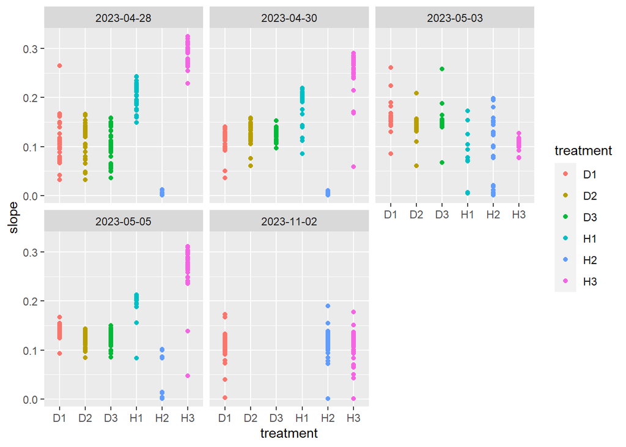

```r
# d %>% ggplot() + geom_point(aes(x=as.character(date), y=slope, color=category))

d %>%
  filter(category == 'Ctrl.H' | category == 'Ctrl.D') %>% ggplot() + geom_point(aes(x=treatment, y=slope, color=treatment)) + facet_wrap(vars(date))
```

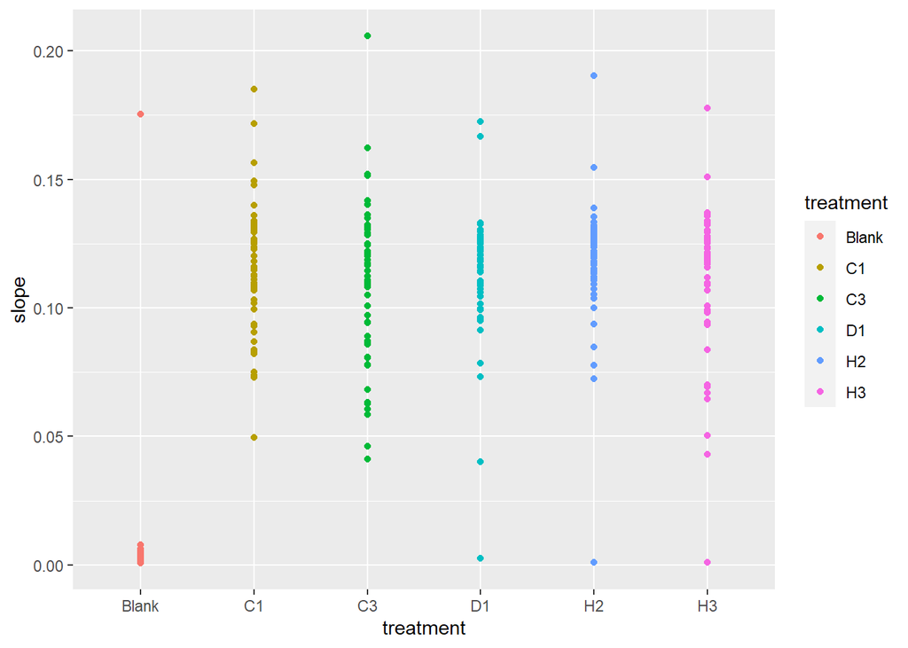

```r
d %>%
  filter(date == mdy(11022023)) %>% ggplot() +
  geom_point(aes(x=treatment, y=slope, color=treatment))
```

Outlier Hunt

```r
d %>% slice_min(order_by = slope, n=30)
```

```
##    well treatment        slope initial     final       date batch label
## 1   H13        H2 0.0004391908 0.26250 0.2351919 2023-05-05     2   103
## 2    M2        H2 0.0004490511 0.24075 0.2165051 2023-05-05     2   103
## 3    J3        H2 0.0004648580 0.50225 0.4510057 2023-04-28     2   103
## 4    D1        H2 0.0004768408 0.22800 0.2072020 2023-05-05     2   103
## 5    J3        H2 0.0004862728 0.24175 0.2200960 2023-05-05     2   103
## 6    G8     Blank 0.0006133644 0.35900 0.3491667 2023-11-02     2     0
## 7    I8     Blank 0.0006315432 0.36725 0.3513232 2023-11-02     2     0
## 8   P19        H2 0.0006398804 0.26175 0.2270606 2023-04-30     2   103
## 9   I21     Blank 0.0006404007 0.38325 0.3812525 2023-11-02     2     0
## 10   D3        H2 0.0006464416 0.24475 0.2073678 2023-04-28     2   103
## 11   G2        H2 0.0006520980 0.25825 0.2264495 2023-04-30     2   103
## 12  K21     Blank 0.0006528853 0.39000 0.3878990 2023-11-02     2     0
## 13   M2        H2 0.0006585941 0.24700 0.2185354 2023-04-30     2   103
## 14  G21     Blank 0.0006588590 0.36675 0.3680354 2023-11-02     2     0
```

[output cut: 47 more lines]

```r
mean(d$slope)
```

```
## [1] 0.113962
```

```r
median(d$slope)
```

```
## [1] 0.1179777
```

```r
min(d$slope)
```

```
## [1] 0.0004391908
```

```r
max(d$slope)
```

```
## [1] 0.325352
```

```r
# d %>% filter(slope > 0.010) %>% ggplot() + geom_point(aes(x=category, y=slope, color=category)) + facet_wrap(vars(date))
```

Trying a linear model to set a cutoff for the blanks which can then be used to remove the other outliers

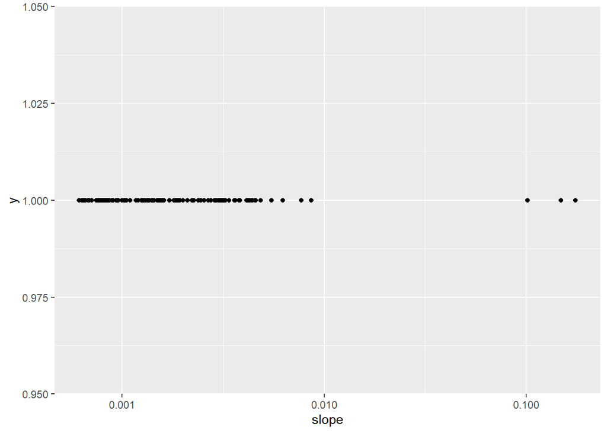

```r
blanks <-  d %>% filter(category == 'Blank')
blanks %>% ggplot() + geom_point(aes(x=slope, y=1)) +
  scale_x_log10()
```

```r
# setting cutoff for blanks around
bad.blanks <- blanks %>% filter(slope > 0.05)
good.blanks <- blanks %>% filter(slope < 0.05)

model <- lmer(slope~(1|date), data = good.blanks)
dates.predict <- data.frame(date=distinct(d, date))
# dates.predict$batch <- c(rep(1,4), rep(2,4))
dates.predict$null = predict(model, dates.predict)
```

Outlier Analysis

```r
data <- d %>%
  filter(initial <= final) %>%
  anti_join(bad.blanks) %>%
  full_join(dates.predict, by=join_by(date)) %>%
  filter(slope >= null) %>%
  filter(!(treatment %in% anc.hap.fake))
```

[output not shown]

```r
diff <- anti_join(d, data)
```

[output not shown]

```r
diff %>% filter(date == ymd(20230503)) %>% select(well) %>% as.vector()
```

```
## $well
##  [1] "A1"  "B1"  "D1"  "G1"  "H1"  "J1"  "M1"  "N1"  "P1"  "B2"  "D2"  "E2"
## [13] "G2"  "J2"  "K2"  "M2"  "P2"  "A3"  "G3"  "H3"  "M3"  "N3"  "A4"  "P4"
## [25] "O5"  "P5"  "A6"  "O6"  "B7"  "B8"  "A9"  "A10" "B10" "P10" "O11" "P11"
## [37] "H12" "K12" "L12" "O12" "B13" "E13" "F13" "B14" "O14" "A15" "A16" "P16"
## [49] "O17" "P17" "A18" "O18" "B19" "B20" "A21" "A22" "D22" "E22" "F22" "J22"
## [61] "K22" "P22" "A23" "B23" "D23" "G23" "H23" "M23" "N23" "P23" "A24" "D24"
## [73] "E24" "J24" "K24" "O24" "P24"
```

```r
diff %>% filter(date == ymd(20230505)) %>% select(well) %>% as.vector()
```

```
## $well
##  [1] "A1"  "B1"  "D1"  "G1"  "H1"  "J1"  "M1"  "N1"  "P1"  "B2"  "D2"  "E2"
## [13] "G2"  "J2"  "K2"  "M2"  "P2"  "A3"  "D3"  "G3"  "H3"  "J3"  "M3"  "N3"
## [25] "A4"  "B4"  "P4"  "O5"  "P5"  "A6"  "O6"  "B7"  "B8"  "O8"  "A9"  "A10"
## [37] "B10" "P10" "O11" "P11" "A12" "K12" "L12" "N12" "O12" "B13" "E13" "F13"
## [49] "H13" "P13" "B14" "O14" "A15" "A16" "B16" "P16" "O17" "P17" "A18" "O18"
## [61] "B19" "P19" "B20" "O20" "A21" "A22" "B22" "D22" "E22" "G22" "J22" "K22"
## [73] "M22" "P22" "A23" "B23" "D23" "G23" "H23" "J23" "M23" "N23" "P23" "A24"
## [85] "D24" "E24" "G24" "J24" "K24" "M24" "O24"
```

```r
diff %>% filter(date == ymd(20230428)) %>% select(well) %>% as.vector()
```

```
## $well
##  [1] "B1"  "D1"  "G1"  "H1"  "J1"  "M1"  "N1"  "P1"  "B2"  "D2"  "E2"  "G2"
## [13] "J2"  "K2"  "M2"  "P2"  "A3"  "D3"  "G3"  "H3"  "J3"  "M3"  "N3"  "A4"
## [25] "B4"  "P4"  "O5"  "P5"  "A6"  "O6"  "B7"  "P7"  "B8"  "O8"  "A9"  "A10"
## [37] "B10" "P10" "O11" "P11" "A12" "C12" "H12" "K12" "L12" "N12" "O12" "B13"
## [49] "E13" "F13" "H13" "P13" "B14" "O14" "A15" "A16" "B16" "P16" "O17" "P17"
## [61] "A18" "O18" "B19" "P19" "B20" "O20" "A21" "A22" "B22" "D22" "E22" "G22"
## [73] "J22" "K22" "M22" "P22" "A23" "B23" "D23" "G23" "H23" "J23" "M23" "N23"
## [85] "P23" "A24" "D24" "E24" "G24" "J24" "K24" "M24" "O24"
```

```r
diff %>% filter(date == ymd(20230430)) %>% select(well) %>% as.vector()
```

```
## $well
##  [1] "A1"  "B1"  "D1"  "G1"  "H1"  "J1"  "M1"  "N1"  "P1"  "B2"  "D2"  "E2"
## [13] "G2"  "J2"  "K2"  "M2"  "P2"  "A3"  "D3"  "G3"  "H3"  "J3"  "M3"  "N3"
## [25] "A4"  "B4"  "P4"  "O5"  "P5"  "O6"  "B7"  "B8"  "O8"  "A9"  "A10" "P10"
## [37] "O11" "P11" "A12" "B12" "H12" "K12" "L12" "N12" "O12" "B13" "E13" "F13"
## [49] "H13" "P13" "B14" "O14" "A15" "B16" "P16" "A17" "O17" "P17" "O18" "B19"
## [61] "P19" "A20" "B20" "O20" "A21" "B22" "D22" "E22" "G22" "J22" "K22" "M22"
## [73] "P22" "A23" "B23" "D23" "G23" "H23" "J23" "M23" "N23" "P23" "A24" "D24"
## [85] "E24" "J24" "K24" "M24" "O24" "P24"
```

Data Analysis

```r
data <- data %>% select(date, well, treatment, label, category, slope) %>%
  filter(category != 'Blank')
data$ploidy <- case_when(
  data$category %in% c('Ctrl.H', 'MA.H') ~ 'Haploid',
  data$category %in% c('Ctrl.D', 'MA.D') ~ 'Diploid'
)
data$MA <- case_when(
  data$category %in% c('MA.H', 'MA.D') ~ 'MA',
  data$category %in% c('Ctrl.H', 'Ctrl.D') ~ 'Ctrl',
)
```

Relative fitness calculations

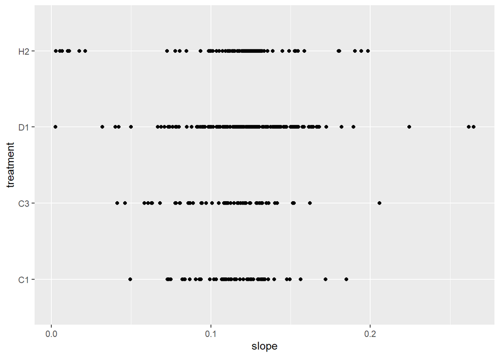

```r
trt <- data %>% filter(label > 0 & label <= 100)
ctrl <- data %>% filter(label > 100)

# Try filtering based on the control info
ctrl <- ctrl %>% filter(treatment != 'H1') %>%
  filter(treatment != 'H3')
ctrl %>% ggplot() +
  geom_point(aes(x=slope, y=treatment))
```

```r
# previous code
mod <- lmer(slope ~ ploidy + (1|date), ctrl)
ctrl.predict <- data.frame(distinct(ctrl, date, ploidy))
ctrl.predict$ctrl <- predict(mod, ctrl.predict)
trt <- left_join(trt, ctrl.predict, by=c('date', 'ploidy'))
trt$rel.fit <- trt$slope - trt$ctrl

trt <- trt %>% group_by(ploidy, label) %>%
  summarize(rel.fit = mean(rel.fit)) %>%
  ungroup()
```

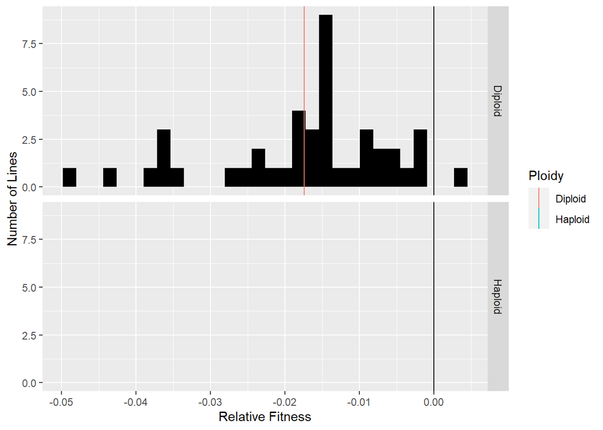

```r
mu.dip <- mean(trt$rel.fit[trt$ploidy == 'Diploid'])
sd.dip <- sd(trt$rel.fit[trt$ploidy == 'Diploid'])

mu.hap <- mean(trt$rel.fit[trt$ploidy == 'Haploid'])
sd.hap <- sd(trt$rel.fit[trt$ploidy == 'Haploid'])


trt %>% ggplot() +
  geom_histogram(aes(x=rel.fit), fill='black') +
  facet_grid(rows = vars(ploidy)) +
  geom_vline(data = data.frame(ploidy = c('Haploid', 'Diploid'),
                               mu = c(mu.hap, mu.dip)),
             aes(xintercept = mu, color = ploidy)) +
  geom_vline(xintercept = 0, color = 'black') +
  xlab("Relative Fitness") +
  ylab("Number of Lines") +
  guides(color = guide_legend(title = "Ploidy"))
```

```r
# vioplot(trt[trt$ploidy == 'Haploid',]$rel.fit,
#         trt[trt$ploidy == 'Diploid',]$rel.fit,
#         names = c("Haploid", "Diploid"),
#         col = c('red', 'blue'),
#         ylim = c(-0.15, 0))
```

lmer for hypothesis testing

```r
null <- lmer(slope ~ MA + ploidy + (1|date) + (1|treatment), data)
summary(null)
```

```
## Linear mixed model fit by REML ['lmerMod']
## Formula: slope ~ MA + ploidy + (1 | date) + (1 | treatment)
##    Data: data
##
## REML criterion at convergence: -4425.6
##
## Scaled residuals:
##     Min      1Q  Median      3Q     Max
## -3.2668 -0.5561  0.0744  0.6275  3.6691
##
## Random effects:
##  Groups    Name        Variance  Std.Dev.
##  treatment (Intercept) 0.0001398 0.01182
##  date      (Intercept) 0.0003598 0.01897
##  Residual              0.0022766 0.04771
## Number of obs: 1390, groups:  treatment, 98; date, 5
##
## Fixed effects:
##                Estimate Std. Error t value
## (Intercept)    0.143634   0.010981  13.080
## MAMA          -0.042754   0.006766  -6.319
## ploidyHaploid  0.013537   0.004062   3.333
##
## Correlation of Fixed Effects:
##             (Intr) MAMA
## MAMA        -0.567
## ploidyHapld -0.270  0.097
```

```r
full <- lmer(slope ~ MA*ploidy + (1|date) + (1|treatment), data)
summary(full)
```

```
## Linear mixed model fit by REML ['lmerMod']
## Formula: slope ~ MA * ploidy + (1 | date) + (1 | treatment)
##    Data: data
##
## REML criterion at convergence: -4420.4
##
## Scaled residuals:
##     Min      1Q  Median      3Q     Max
## -3.2726 -0.5534  0.0777  0.6309  3.6787
##
## Random effects:
##  Groups    Name        Variance  Std.Dev.
##  treatment (Intercept) 0.0001379 0.01174
##  date      (Intercept) 0.0003569 0.01889
##  Residual              0.0022767 0.04771
## Number of obs: 1390, groups:  treatment, 98; date, 5
##
## Fixed effects:
##                    Estimate Std. Error t value
## (Intercept)         0.13146    0.01492   8.810
## MAMA               -0.02976    0.01275  -2.333
## ploidyHaploid       0.02994    0.01427   2.098
## MAMA:ploidyHaploid -0.01782    0.01488  -1.197
##
## Correlation of Fixed Effects:
##             (Intr) MAMA   pldyHp
## MAMA        -0.797
## ploidyHapld -0.709  0.829
## MAMA:pldyHp  0.681 -0.850 -0.959
```

```r
mod <- anova(null, full)
```

```
## refitting model(s) with ML (instead of REML)
```

```r
mod
```

```
## Data: data
## Models:
## null: slope ~ MA + ploidy + (1 | date) + (1 | treatment)
## full: slope ~ MA * ploidy + (1 | date) + (1 | treatment)
##      npar     AIC     BIC logLik deviance  Chisq Df Pr(>Chisq)
## null    6 -4438.7 -4407.3 2225.3  -4450.7
## full    7 -4438.2 -4401.5 2226.1  -4452.2 1.5158  1     0.2183
```

```r
full <- lmer(slope ~ MA + (1|date) + (1|treatment), data)
null <- lmer(slope ~ 1 + (1|date) + (1|treatment), data)
mod <- anova(null, full)
```

```
## refitting model(s) with ML (instead of REML)
```

```r
mod
```

```
## Data: data
## Models:
## null: slope ~ 1 + (1 | date) + (1 | treatment)
## full: slope ~ MA + (1 | date) + (1 | treatment)
##      npar     AIC     BIC logLik deviance  Chisq Df Pr(>Chisq)
## null    4 -4401.9 -4381.0   2205  -4409.9
## full    5 -4430.1 -4403.9   2220  -4440.1 30.113  1  4.077e-08 ***
## ---
## Signif. codes:  0 '***' 0.001 '**' 0.01 '*' 0.05 '.' 0.1 ' ' 1
```

```r
full <- lmer(slope ~ ploidy + (1|date) + (1|treatment), data)
null <- lmer(slope ~ 1 + (1|date) + (1|treatment), data)
mod <- anova(null, full)
```

```
## refitting model(s) with ML (instead of REML)
```

```r
mod
```

```
## Data: data
## Models:
## null: slope ~ 1 + (1 | date) + (1 | treatment)
## full: slope ~ ploidy + (1 | date) + (1 | treatment)
##      npar     AIC     BIC logLik deviance Chisq Df Pr(>Chisq)
## null    4 -4401.9 -4381.0 2205.0  -4409.9
## full    5 -4409.6 -4383.4 2209.8  -4419.6 9.689  1   0.001854 **
## ---
## Signif. codes:  0 '***' 0.001 '**' 0.01 '*' 0.05 '.' 0.1 ' ' 1
```

```r
#2023 10 30
full <- lmer(slope ~ MA + ploidy + (1|date) + (1|treatment), data)
null <- lmer(slope ~ MA + (1|date) + (1|treatment), data)
mod <- anova(null, full)
```

```
## refitting model(s) with ML (instead of REML)
```

```r
mod
```

```
## Data: data
## Models:
## null: slope ~ MA + (1 | date) + (1 | treatment)
## full: slope ~ MA + ploidy + (1 | date) + (1 | treatment)
##      npar     AIC     BIC logLik deviance  Chisq Df Pr(>Chisq)
## null    5 -4430.1 -4403.9 2220.0  -4440.1
## full    6 -4438.7 -4407.3 2225.3  -4450.7 10.625  1   0.001116 **
## ---
## Signif. codes:  0 '***' 0.001 '**' 0.01 '*' 0.05 '.' 0.1 ' ' 1
```

```r
full <- lmer(slope ~ ploidy + MA + (1|date) + (1|treatment), data)
null <- lmer(slope ~ ploidy + (1|date) + (1|treatment), data)
mod <- anova(null, full)
```

```
## refitting model(s) with ML (instead of REML)
```

```r
mod
```

```
## Data: data
## Models:
## null: slope ~ ploidy + (1 | date) + (1 | treatment)
## full: slope ~ ploidy + MA + (1 | date) + (1 | treatment)
##      npar     AIC     BIC logLik deviance  Chisq Df Pr(>Chisq)
## null    5 -4409.6 -4383.4 2209.8  -4419.6
## full    6 -4438.7 -4407.3 2225.3  -4450.7 31.049  1  2.517e-08 ***
## ---
## Signif. codes:  0 '***' 0.001 '**' 0.01 '*' 0.05 '.' 0.1 ' ' 1
```

```r
#old
full <- lmer(slope ~ ploidy + (1|date) + (1|treatment), data[data$MA == 'MA',])
summary(full)
```

```
## Linear mixed model fit by REML ['lmerMod']
## Formula: slope ~ ploidy + (1 | date) + (1 | treatment)
##    Data: data[data$MA == "MA", ]
##
## REML criterion at convergence: -3390.9
##
## Scaled residuals:
##     Min      1Q  Median      3Q     Max
## -3.2461 -0.5788  0.0464  0.4741  6.1160
##
## Random effects:
##  Groups    Name        Variance  Std.Dev.
##  treatment (Intercept) 0.0000597 0.007727
##  date      (Intercept) 0.0002448 0.015647
##  Residual              0.0009714 0.031167
## Number of obs: 845, groups:  treatment, 94; date, 5
##
## Fixed effects:
##               Estimate Std. Error t value
## (Intercept)   0.108622   0.007394  14.691
## ploidyHaploid 0.009051   0.002806   3.225
##
## Correlation of Fixed Effects:
##             (Intr)
## ploidyHapld -0.234
```

```r
null <- lmer(slope ~ 1 + (1|date) + (1|treatment), data[data$MA == 'MA',])
mod <- anova(null, full)
```

```
## refitting model(s) with ML (instead of REML)
```

```r
mod
```

```
## Data: data[data$MA == "MA", ]
## Models:
## null: slope ~ 1 + (1 | date) + (1 | treatment)
## full: slope ~ ploidy + (1 | date) + (1 | treatment)
##      npar   AIC     BIC logLik deviance  Chisq Df Pr(>Chisq)
## null    4 -3391 -3372.1 1699.5    -3399
## full    5 -3399 -3375.3 1704.5    -3409 9.9377  1   0.001619 **
## ---
## Signif. codes:  0 '***' 0.001 '**' 0.01 '*' 0.05 '.' 0.1 ' ' 1
```

```r
#2023 10 26
full <- lmer(slope ~ ploidy + (1|date) + (1|treatment), data[data$MA == 'MA',])
summary(full)
```

```
## Linear mixed model fit by REML ['lmerMod']
## Formula: slope ~ ploidy + (1 | date) + (1 | treatment)
##    Data: data[data$MA == "MA", ]
##
## REML criterion at convergence: -3390.9
##
## Scaled residuals:
##     Min      1Q  Median      3Q     Max
## -3.2461 -0.5788  0.0464  0.4741  6.1160
##
## Random effects:
##  Groups    Name        Variance  Std.Dev.
##  treatment (Intercept) 0.0000597 0.007727
##  date      (Intercept) 0.0002448 0.015647
##  Residual              0.0009714 0.031167
## Number of obs: 845, groups:  treatment, 94; date, 5
##
## Fixed effects:
##               Estimate Std. Error t value
## (Intercept)   0.108622   0.007394  14.691
## ploidyHaploid 0.009051   0.002806   3.225
##
## Correlation of Fixed Effects:
##             (Intr)
## ploidyHapld -0.234
```

```r
null <- lmer(slope ~ ploidy + (1|date), data[data$MA == 'MA',])
mod <- anova(null, full)
```

```
## refitting model(s) with ML (instead of REML)
```

```r
mod
```

```
## Data: data[data$MA == "MA", ]
## Models:
## null: slope ~ ploidy + (1 | date)
## full: slope ~ ploidy + (1 | date) + (1 | treatment)
##      npar     AIC     BIC logLik deviance  Chisq Df Pr(>Chisq)
## null    4 -3393.9 -3374.9 1701.0  -3401.9
## full    5 -3399.0 -3375.3 1704.5  -3409.0 7.0943  1   0.007733 **
## ---
## Signif. codes:  0 '***' 0.001 '**' 0.01 '*' 0.05 '.' 0.1 ' ' 1
```

```r
full.hap <- lmer(slope ~ 1 + (1|date) + (1|treatment), data[data$MA == 'MA' & data$ploidy =='Haploid',])
null.hap <- lmer(slope ~ 1 + (1|date), data[data$MA == 'MA' & data$ploidy =='Haploid',])
anova(full.hap, null.hap)
```

```
## refitting model(s) with ML (instead of REML)
```

```
## Data: data[data$MA == "MA" & data$ploidy == "Haploid", ]
## Models:
## null.hap: slope ~ 1 + (1 | date)
## full.hap: slope ~ 1 + (1 | date) + (1 | treatment)
##          npar     AIC     BIC logLik deviance  Chisq Df Pr(>Chisq)
## null.hap    3 -1949.0 -1936.4 977.51  -1955.0
## full.hap    4 -1952.3 -1935.4 980.14  -1960.3 5.2572  1    0.02186 *
## ---
## Signif. codes:  0 '***' 0.001 '**' 0.01 '*' 0.05 '.' 0.1 ' ' 1
```

```r
full.hap <- lmer(slope ~ 1 + (1|date) + (1|treatment), data[data$MA == 'Ctrl' & data$ploidy =='Haploid',])
null.hap <- lmer(slope ~ 1 + (1|date), data[data$MA == 'Ctrl' & data$ploidy =='Haploid',])
anova(full.hap, null.hap)
```

```
## refitting model(s) with ML (instead of REML)
```

```
## Data: data[data$MA == "Ctrl" & data$ploidy == "Haploid", ]
## Models:
## null.hap: slope ~ 1 + (1 | date)
## full.hap: slope ~ 1 + (1 | date) + (1 | treatment)
##          npar     AIC     BIC logLik deviance  Chisq Df Pr(>Chisq)
## null.hap    3 -1119.8 -1108.0 562.88  -1125.8
## full.hap    4 -1224.3 -1208.6 616.14  -1232.3 106.52  1  < 2.2e-16 ***
## ---
## Signif. codes:  0 '***' 0.001 '**' 0.01 '*' 0.05 '.' 0.1 ' ' 1
```

```r
full.dip <- lmer(slope ~ 1 + (1|date) + (1|treatment), data[data$MA == 'MA' & data$ploidy =='Diploid',])
confint(full.hap)
```

```
## Computing profile confidence intervals ...
```

```
##                  2.5 %     97.5 %
## .sig01      0.04218171 0.15642973
## .sig02      0.01528339 0.10326058
## .sigma      0.04088571 0.04728336
## (Intercept) 0.09082828 0.25893306
```

```r
confint(full.dip)
```

```
## Computing profile confidence intervals ...
```

```
##                   2.5 %     97.5 %
## .sig01      0.002316880 0.01178378
## .sig02      0.009415743 0.04230173
## .sigma      0.024428388 0.02868695
## (Intercept) 0.087845155 0.13189942
```

```r
confint.merMod(full.hap) # or just use confint
```

```
## Computing profile confidence intervals ...
```

```
##                  2.5 %     97.5 %
## .sig01      0.04218171 0.15642973
## .sig02      0.01528339 0.10326058
## .sigma      0.04088571 0.04728336
## (Intercept) 0.09082828 0.25893306
```

```r
confint.merMod(full.dip)
```

```
## Computing profile confidence intervals ...
```

```
##                   2.5 %     97.5 %
## .sig01      0.002316880 0.01178378
## .sig02      0.009415743 0.04230173
## .sigma      0.024428388 0.02868695
## (Intercept) 0.087845155 0.13189942
```

```r
mod
```

```
## Data: data[data$MA == "MA", ]
## Models:
## null: slope ~ ploidy + (1 | date)
## full: slope ~ ploidy + (1 | date) + (1 | treatment)
##      npar     AIC     BIC logLik deviance  Chisq Df Pr(>Chisq)
## null    4 -3393.9 -3374.9 1701.0  -3401.9
## full    5 -3399.0 -3375.3 1704.5  -3409.0 7.0943  1   0.007733 **
## ---
## Signif. codes:  0 '***' 0.001 '**' 0.01 '*' 0.05 '.' 0.1 ' ' 1
```

```r
#old
full <- lmer(slope ~ ploidy + (1|date) + (1|treatment), data[data$MA == 'Ctrl',])
summary(full)
```

```
## Linear mixed model fit by REML ['lmerMod']
## Formula: slope ~ ploidy + (1 | date) + (1 | treatment)
##    Data: data[data$MA == "Ctrl", ]
##
## REML criterion at convergence: -1617.2
##
## Scaled residuals:
##     Min      1Q  Median      3Q     Max
## -3.6058 -0.6437  0.1827  0.7072  3.4504
##
## Random effects:
##  Groups    Name        Variance  Std.Dev.
##  date      (Intercept) 0.0021983 0.04689
##  treatment (Intercept) 0.0007524 0.02743
##  Residual              0.0027908 0.05283
## Number of obs: 545, groups:  date, 5; treatment, 4
##
## Fixed effects:
##               Estimate Std. Error t value
## (Intercept)    0.13345    0.03476   3.839
## ploidyHaploid  0.03345    0.03206   1.044
##
## Correlation of Fixed Effects:
##             (Intr)
## ploidyHapld -0.689
```

```r
null <- lmer(slope ~ 1 + (1|date) + (1|treatment), data[data$MA == 'Ctrl',])
mod <- anova(null, full)
```

```
## refitting model(s) with ML (instead of REML)
```

```r
mod
```

```
## Data: data[data$MA == "Ctrl", ]
## Models:
## null: slope ~ 1 + (1 | date) + (1 | treatment)
## full: slope ~ ploidy + (1 | date) + (1 | treatment)
##      npar     AIC     BIC logLik deviance  Chisq Df Pr(>Chisq)
## null    4 -1618.7 -1601.5 813.35  -1626.7
## full    5 -1618.1 -1596.6 814.07  -1628.1 1.4282  1     0.2321
```

More exploration

Checking consistency of lines

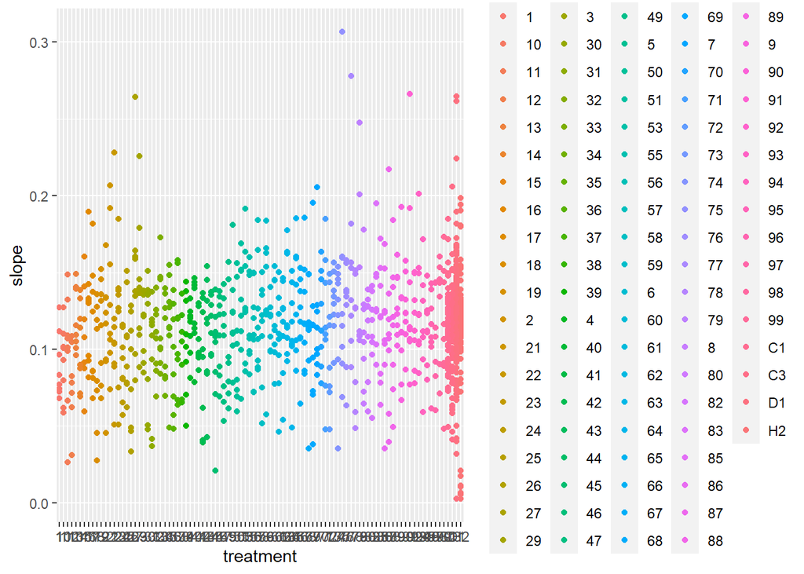

```r
data %>% filter(treatment != 'H1') %>%
  filter(treatment != 'H3') %>%
  ggplot() + geom_point(aes(x=treatment, y=slope, color=treatment))
```

Summarize all collected data for all lines and calculate parameters

```r
df <- data %>%
  group_by(treatment, ploidy, MA) %>%
  summarize(avg = mean(slope),
            var = var(slope),
            sd = sd(slope),
            min = min(slope),
            min.date = data$date[data$slope == min(data$slope)],
            max = max(slope),
            max.date = data$date[data$slope == max(data$slope)]) %>%
  ungroup()
```

Trying some exploratory plots for variance

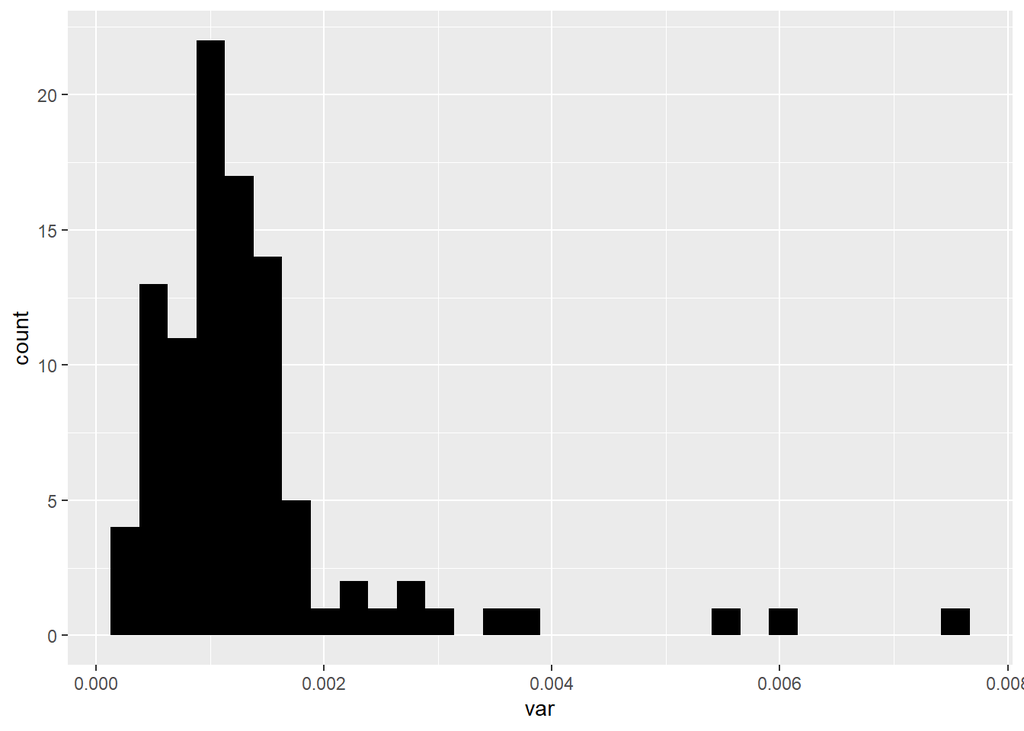

```r
df %>% ggplot() + geom_histogram(aes(x=var), fill = 'black')
```

```r
df %>% filter(var > 0.0025)
```

```
## # A tibble: 9 × 10
##   treatment ploidy  MA      avg     var     sd     min min.date     max
##   <chr>     <chr>   <chr> <dbl>   <dbl>  <dbl>   <dbl> <date>     <dbl>
## 1 22        Diploid MA    0.113 0.00263 0.0512 0.0511  2023-11-02 0.228
## 2 27        Haploid MA    0.150 0.00308 0.0555 0.0799  2023-11-02 0.264
## 3 75        Haploid MA    0.141 0.00550 0.0742 0.0688  2023-11-02 0.307
## 4 77        Haploid MA    0.152 0.00347 0.0589 0.0883  2023-11-02 0.278
## 5 79        Haploid MA    0.143 0.00288 0.0537 0.106   2023-11-02 0.247
## 6 87        Haploid MA    0.111 0.00286 0.0535 0.0398  2023-11-02 0.217
## 7 91        Haploid MA    0.140 0.00377 0.0614 0.0769  2023-11-02 0.266
## 8 H1        Haploid Ctrl  0.157 0.00614 0.0784 0.00429 2023-11-02 0.243
## 9 H3        Haploid Ctrl  0.191 0.00750 0.0866 0.0429  2023-11-02 0.325
## # ℹ 1 more variable: max.date <date>
```

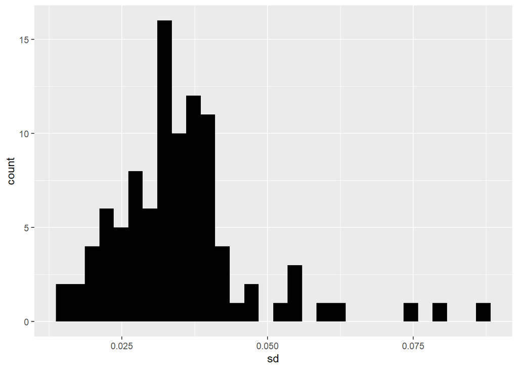

```r
df %>% ggplot() + geom_histogram(aes(x=sd), fill = 'black')
```

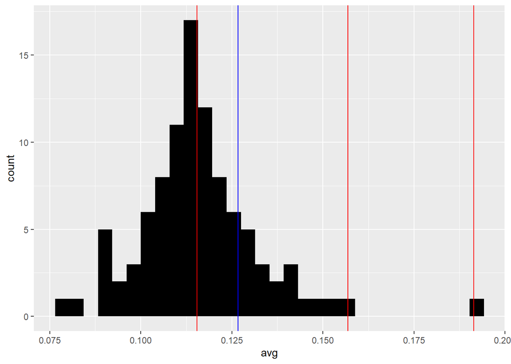

```r
df %>% ggplot() + geom_histogram(aes(x=avg), fill = 'black') +
  geom_vline(xintercept = df$avg[df$ploidy == 'Haploid' &
                               df$MA == 'Ctrl'], color='Red') +
  geom_vline(xintercept = df$avg[df$ploidy == 'Diploid' &
                               df$MA == 'Ctrl'], color='Blue')
```

```r
df %>% filter(avg > 0.2)
```

```
## # A tibble: 0 × 10
## # ℹ 10 variables: treatment <chr>, ploidy <chr>, MA <chr>, avg <dbl>,
## #   var <dbl>, sd <dbl>, min <dbl>, min.date <date>, max <dbl>, max.date <date>
```

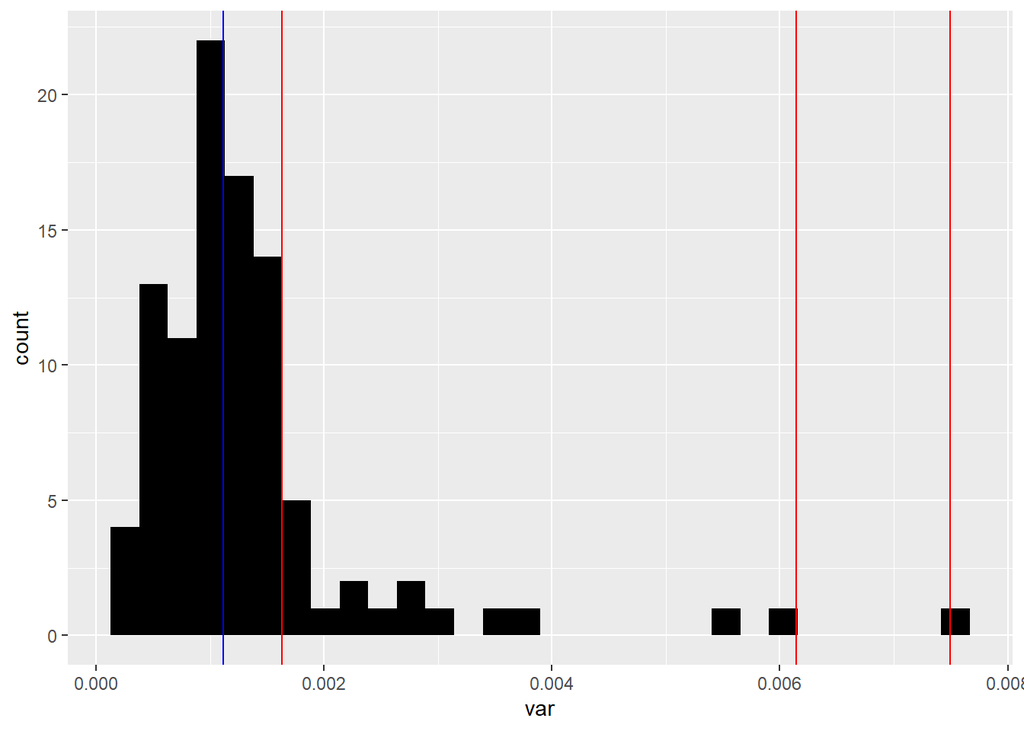

```r
df %>% ggplot() + geom_histogram(aes(x=var), fill = 'black') +
  geom_vline(xintercept = df$var[df$ploidy == 'Haploid' &
                               df$MA == 'Ctrl'], color='Red') +
  geom_vline(xintercept = df$var[df$ploidy == 'Diploid' &
                               df$MA == 'Ctrl'], color='Blue')
```

```r
mod <- lm(var ~ ploidy*MA, df)
summary(mod)
```

```
##
## Call:
## lm(formula = var ~ ploidy * MA, data = df)
##
## Residuals:
##        Min         1Q     Median         3Q        Max
## -0.0034599 -0.0004128 -0.0001298  0.0002630  0.0040491
##
## Coefficients:
##                      Estimate Std. Error t value Pr(>|t|)
## (Intercept)         1.114e-03  8.921e-04   1.248 0.214982
## ploidyHaploid       3.976e-03  1.030e-03   3.860 0.000208 ***
## MAMA               -8.282e-05  9.024e-04  -0.092 0.927074
## ploidyHaploid:MAMA -3.556e-03  1.047e-03  -3.398 0.000998 ***
## ---
## Signif. codes:  0 '***' 0.001 '**' 0.01 '*' 0.05 '.' 0.1 ' ' 1
##
## Residual standard error: 0.0008921 on 94 degrees of freedom
## Multiple R-squared:  0.3851, Adjusted R-squared:  0.3655
## F-statistic: 19.62 on 3 and 94 DF,  p-value: 5.839e-10
```

```r
mod <- lm(var ~ ploidy, df[df$MA == 'Ctrl',])
summary(mod)
```

```
##
## Call:
## lm(formula = var ~ ploidy, data = df[df$MA == "Ctrl", ])
##
## Residuals:
##          1          2          3          4
## -2.168e-19  1.052e-03 -3.460e-03  2.408e-03
##
## Coefficients:
##               Estimate Std. Error t value Pr(>|t|)
## (Intercept)   0.001114   0.003072   0.363    0.752
## ploidyHaploid 0.003976   0.003547   1.121    0.379
##
## Residual standard error: 0.003072 on 2 degrees of freedom
## Multiple R-squared:  0.3858, Adjusted R-squared:  0.07869
## F-statistic: 1.256 on 1 and 2 DF,  p-value: 0.3789
```

```r
mod <- lm(var ~ ploidy, df[df$MA == 'MA',])
summary(mod)
```

```
##
## Call:
## lm(formula = var ~ ploidy, data = df[df$MA == "MA", ])
##
## Residuals:
##        Min         1Q     Median         3Q        Max
## -0.0011899 -0.0004128 -0.0001400  0.0002567  0.0040491
##
## Coefficients:
##                Estimate Std. Error t value Pr(>|t|)
## (Intercept)   0.0010309  0.0001189   8.670 1.43e-13 ***
## ploidyHaploid 0.0004199  0.0001614   2.601   0.0108 *
## ---
## Signif. codes:  0 '***' 0.001 '**' 0.01 '*' 0.05 '.' 0.1 ' ' 1
##
## Residual standard error: 0.0007798 on 92 degrees of freedom
## Multiple R-squared:  0.06851,    Adjusted R-squared:  0.05839
## F-statistic: 6.767 on 1 and 92 DF,  p-value: 0.01082
```

```r
mod <- lm(var ~ MA, df[df$ploidy == 'Haploid',])
summary(mod)
```

```
##
## Call:
## lm(formula = var ~ MA, data = df[df$ploidy == "Haploid", ])
##
## Residuals:
##        Min         1Q     Median         3Q        Max
## -0.0034599 -0.0004319 -0.0002058  0.0001569  0.0040491
##
## Coefficients:
##               Estimate Std. Error t value Pr(>|t|)
## (Intercept)  0.0050897  0.0006434   7.911 1.76e-10 ***
## MAMA        -0.0036388  0.0006620  -5.496 1.19e-06 ***
## ---
## Signif. codes:  0 '***' 0.001 '**' 0.01 '*' 0.05 '.' 0.1 ' ' 1
##
## Residual standard error: 0.001114 on 52 degrees of freedom
## Multiple R-squared:  0.3675, Adjusted R-squared:  0.3553
## F-statistic: 30.21 on 1 and 52 DF,  p-value: 1.187e-06
```

```r
mod <- lm(var ~ MA, df[df$ploidy == 'Diploid',])
summary(mod)
```

```
##
## Call:
## lm(formula = var ~ MA, data = df[df$ploidy == "Diploid", ])
##
## Residuals:
##        Min         1Q     Median         3Q        Max
## -8.216e-04 -3.186e-04 -4.282e-05  2.834e-04  1.594e-03
##
## Coefficients:
##               Estimate Std. Error t value Pr(>|t|)
## (Intercept)  1.114e-03  4.937e-04   2.256   0.0293 *
## MAMA        -8.282e-05  4.994e-04  -0.166   0.8691
## ---
## Signif. codes:  0 '***' 0.001 '**' 0.01 '*' 0.05 '.' 0.1 ' ' 1
##
## Residual standard error: 0.0004937 on 42 degrees of freedom
## Multiple R-squared:  0.0006544,  Adjusted R-squared:  -0.02314
## F-statistic: 0.0275 on 1 and 42 DF,  p-value: 0.8691
```

```r
trt <- data %>% filter(label > 0 & label <= 100)
ctrl <- data %>% filter(label > 100)

mod <- lmer(slope ~ ploidy + (1|date), ctrl)
ctrl.predict <- data.frame(distinct(ctrl, date, ploidy))
ctrl.predict$ctrl <- predict(mod, ctrl.predict)
trt <- left_join(trt, ctrl.predict, by=c('date', 'ploidy'))
trt$rel.fit <- trt$slope - trt$ctrl
```

Data Cleanup for d2 (does not exclude ploidy changes)

```r
d2 <- d2 %>% mutate(category = ifelse(label %in% fake.diploids, 'MA.H', category))
d2 <- d2 %>% mutate(category = ifelse(label %in% fake.haploids, 'MA.D', category))
d2 <- d2 %>% filter(batch == 2)
data2 <- d2 %>%
  filter(initial <= final) %>%
  anti_join(bad.blanks) %>%
  full_join(dates.predict, by=join_by(date)) %>%
  filter(slope >= null) %>%
  filter(!(treatment %in% anc.hap.fake))
```

[output not shown]

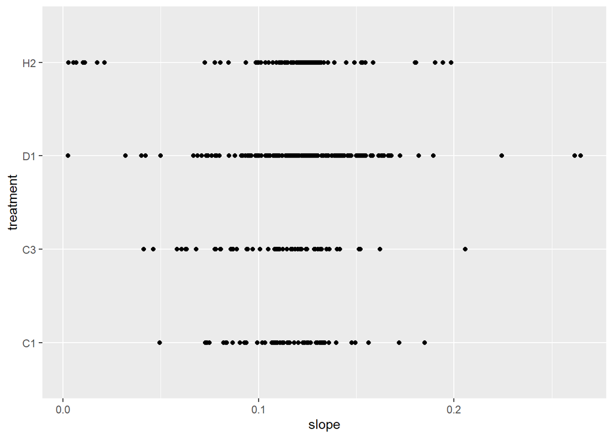

```r
data2 <- data2 %>% select(date, well, treatment, label, category, slope, initial) %>%
  filter(category != 'Blank')
data2$ploidy <- case_when(
  data2$category %in% c('Ctrl.H', 'MA.H') ~ 'Haploid',
  data2$category %in% c('Ctrl.D', 'MA.D') ~ 'Diploid'
)
data2$MA <- case_when(
  data2$category %in% c('MA.H', 'MA.D') ~ 'MA',
  data2$category %in% c('Ctrl.H', 'Ctrl.D') ~ 'Ctrl',
)

trt2 <- data2 %>% filter(label > 0 & label <= 100)
ctrl2 <- data2 %>% filter(label > 100)

# Try filtering based on the control info
ctrl2 <- ctrl2 %>% filter(treatment != 'H1') %>%
  filter(treatment != 'H3')
ctrl2 %>% ggplot() +
  geom_point(aes(x=slope, y=treatment))
```

```r
# previous code
mod2 <- lmer(slope ~ ploidy + (1|date), ctrl2)
ctrl.predict2 <- data.frame(distinct(ctrl, date, ploidy))
ctrl.predict2$ctrl <- predict(mod2, ctrl.predict2)
trt2 <- left_join(trt2, ctrl.predict2, by=c('date', 'ploidy'))
trt2$rel.fit <- trt2$slope - trt2$ctrl
trt2 <- trt2 %>% group_by(ploidy, label) %>%
  summarize(rel.fit = mean(rel.fit)) %>%
  ungroup()
```

Read the mutation data and work with that

```r
mut <- read_delim("pombe_MA_data.txt")
```

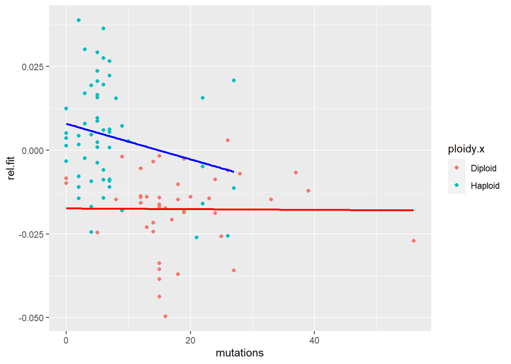

```r
trt2 <- trt2 %>%
  left_join(mut, by=c('label'='line'))
trt2 <- trt2 %>% select(ploidy.x, label, rel.fit, ploidy.y, ploidy_final,
                        n.SNM, n.indel)
trt2 <- trt2 %>% mutate(mutations = n.SNM + n.indel)

trt2 %>% ggplot() +
  geom_point(aes(x=mutations , y=rel.fit, color=ploidy.x)) +
  geom_smooth(data=trt2[trt2$ploidy.x == 'Haploid',],
              mapping=aes(x=mutations, y=rel.fit), color='Blue', method="lm", se=FALSE) +
  geom_smooth(data=trt2[trt2$ploidy.x == 'Diploid',],
              mapping=aes(x=mutations, y=rel.fit), color='Red', method="lm", se=FALSE)
```

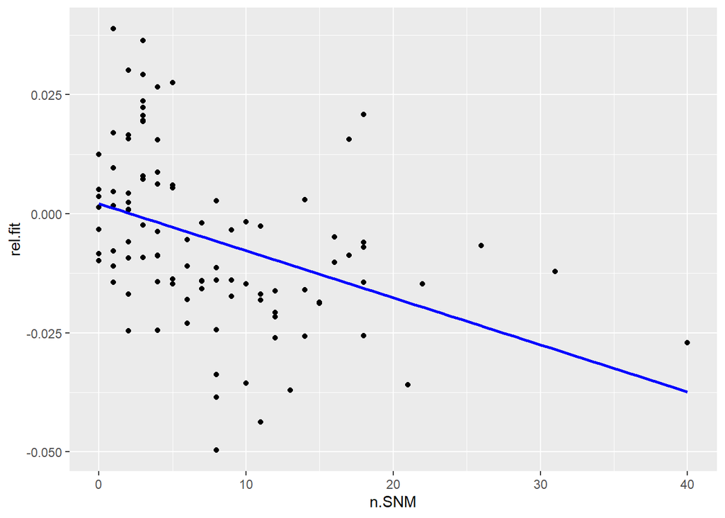

```r
trt2 %>% ggplot() +
  geom_point(aes(x=n.SNM, y=rel.fit)) +
  geom_smooth(aes(x=n.SNM, y=rel.fit), method = "lm", se=FALSE, color='blue')
```

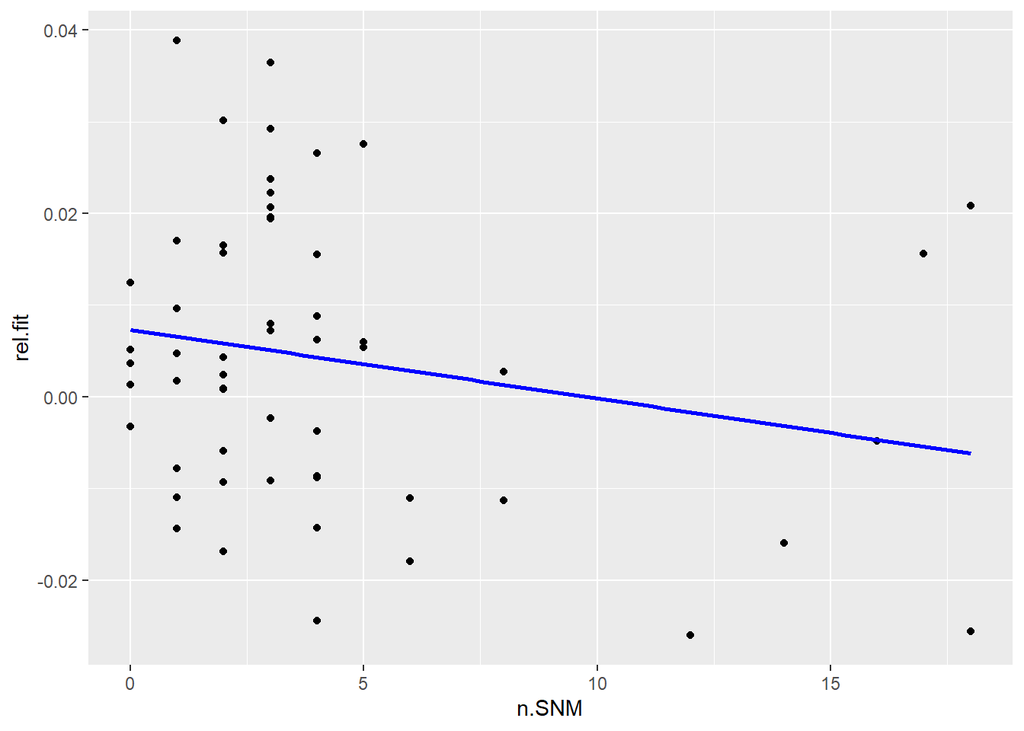

```r
trt2 %>%
  filter(ploidy.x == 'Haploid') %>% ggplot() +
  geom_point(aes(x=n.SNM, y=rel.fit)) +
  geom_smooth(aes(x=n.SNM, y=rel.fit), method = "lm", se=FALSE, color='blue')
```

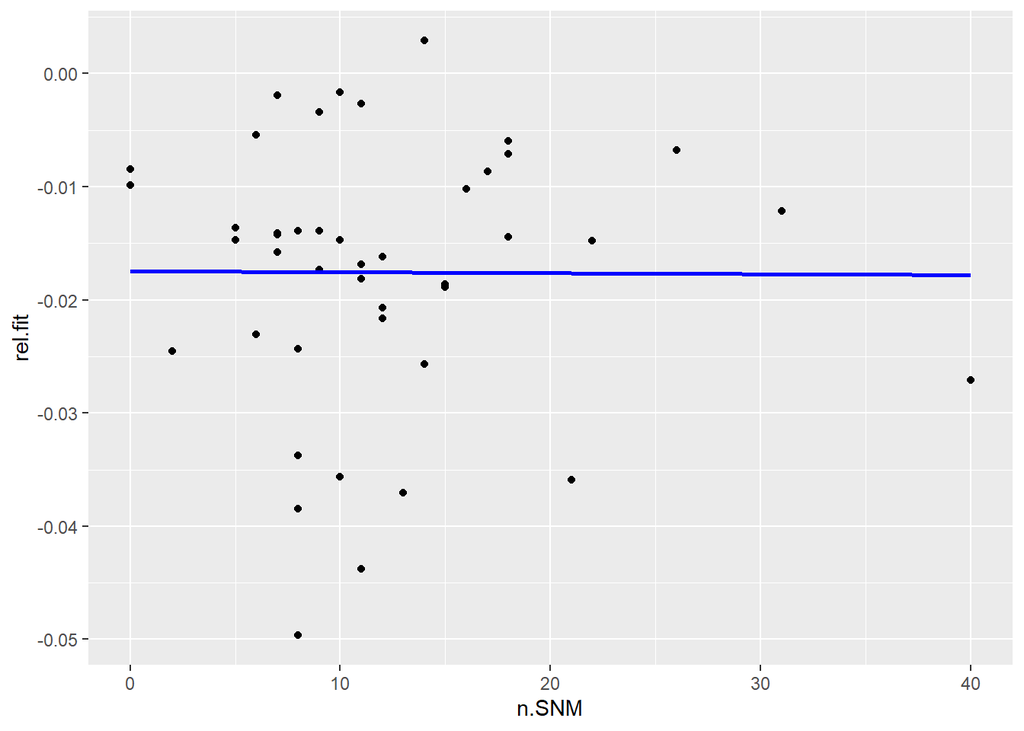

```r
trt2 %>%
  filter(ploidy.x == 'Diploid') %>% ggplot() +
  geom_point(aes(x=n.SNM, y=rel.fit)) +
  geom_smooth(aes(x=n.SNM, y=rel.fit), method = "lm", se=FALSE, color='blue')
```

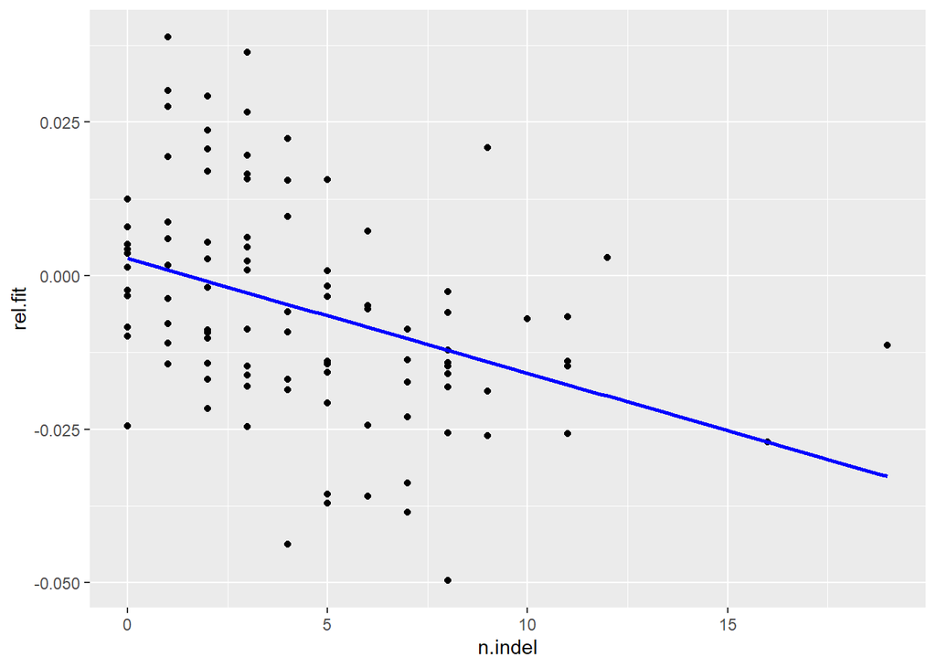

```r
trt2 %>% ggplot() +
  geom_point(aes(x=n.indel, y=rel.fit)) +
  geom_smooth(aes(x=n.indel, y=rel.fit), method = "lm", se=FALSE, color='blue')
```

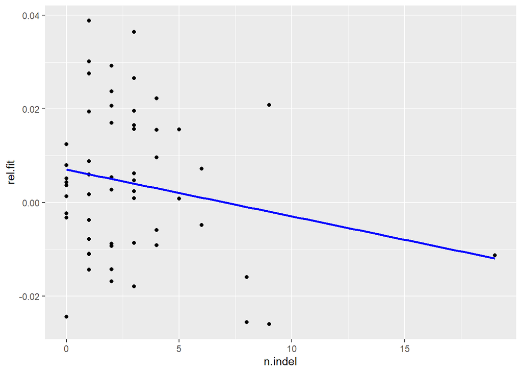

```r
trt2 %>%
  filter(ploidy.x == 'Haploid') %>% ggplot() +
  geom_point(aes(x=n.indel, y=rel.fit)) +
  geom_smooth(aes(x=n.indel, y=rel.fit), method = "lm", se=FALSE, color='blue')
```

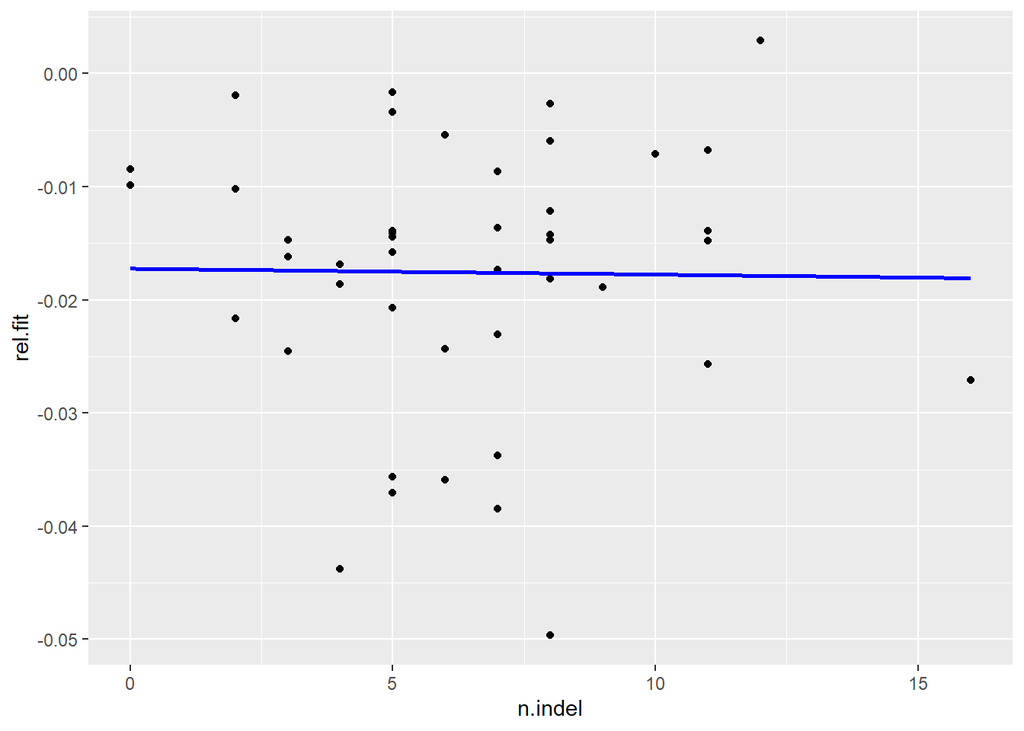

```r
trt2 %>%
  filter(ploidy.x == 'Diploid') %>% ggplot() +
  geom_point(aes(x=n.indel, y=rel.fit)) +
  geom_smooth(aes(x=n.indel, y=rel.fit), method = "lm", se=FALSE, color='blue')
```

```r
mod <- lm(trt2$rel.fit ~ trt2$n.SNM)
summary(mod)
```

```
##
## Call:
## lm(formula = trt2$rel.fit ~ trt2$n.SNM)
##
## Residuals:
##       Min        1Q    Median        3Q       Max
## -0.043893 -0.010554 -0.001185  0.008776  0.037680
##
## Coefficients:
##               Estimate Std. Error t value Pr(>|t|)
## (Intercept)  0.0021381  0.0024040   0.889    0.376
## trt2$n.SNM  -0.0009878  0.0002304  -4.288 4.23e-05 ***
## ---
## Signif. codes:  0 '***' 0.001 '**' 0.01 '*' 0.05 '.' 0.1 ' ' 1
##
## Residual standard error: 0.01642 on 98 degrees of freedom
## Multiple R-squared:  0.158,  Adjusted R-squared:  0.1494
## F-statistic: 18.39 on 1 and 98 DF,  p-value: 4.228e-05
```

```r
mod <- lm(trt2$rel.fit ~ trt2$n.indel)
summary(mod)
```

```
##
## Call:
## lm(formula = trt2$rel.fit ~ trt2$n.indel)
##
## Residuals:
##       Min        1Q    Median        3Q       Max
## -0.039118 -0.011906 -0.001138  0.008841  0.039196
##
## Coefficients:
##                Estimate Std. Error t value Pr(>|t|)
## (Intercept)   0.0028115  0.0026056   1.079    0.283
## trt2$n.indel -0.0018680  0.0004584  -4.075 9.36e-05 ***
## ---
## Signif. codes:  0 '***' 0.001 '**' 0.01 '*' 0.05 '.' 0.1 ' ' 1
##
## Residual standard error: 0.01655 on 98 degrees of freedom
## Multiple R-squared:  0.1449, Adjusted R-squared:  0.1362
## F-statistic: 16.61 on 1 and 98 DF,  p-value: 9.355e-05
```

```r
mod.hap <- lm(rel.fit ~ mutations, trt2[trt2$ploidy.x=='Haploid',])
summary(mod.hap)
```

```
##
## Call:
## lm(formula = rel.fit ~ mutations, data = trt2[trt2$ploidy.x ==
##     "Haploid", ])
##
## Residuals:
##       Min        1Q    Median        3Q       Max
## -0.030212 -0.012393 -0.001836  0.011372  0.031975
##
## Coefficients:
##               Estimate Std. Error t value Pr(>|t|)
## (Intercept)  0.0079174  0.0029846   2.653   0.0105 *
## mutations   -0.0005312  0.0003043  -1.746   0.0866 .
## ---
## Signif. codes:  0 '***' 0.001 '**' 0.01 '*' 0.05 '.' 0.1 ' ' 1
##
## Residual standard error: 0.01552 on 54 degrees of freedom
## Multiple R-squared:  0.05341,    Adjusted R-squared:  0.03588
## F-statistic: 3.047 on 1 and 54 DF,  p-value: 0.08658
```

```r
mod.dip <- lm(rel.fit ~ mutations, trt2[trt2$ploidy.x=='Diploid',])
summary(mod.dip)
```

```
##
## Call:
## lm(formula = rel.fit ~ mutations, data = trt2[trt2$ploidy.x ==
##     "Diploid", ])
##
## Residuals:
##       Min        1Q    Median        3Q       Max
## -0.032126 -0.005857  0.002790  0.007852  0.020550
##
## Coefficients:
##               Estimate Std. Error t value Pr(>|t|)
## (Intercept) -0.0173616  0.0038202  -4.545  4.6e-05 ***
## mutations   -0.0000106  0.0001838  -0.058    0.954
## ---
## Signif. codes:  0 '***' 0.001 '**' 0.01 '*' 0.05 '.' 0.1 ' ' 1
##
## Residual standard error: 0.01198 on 42 degrees of freedom
## Multiple R-squared:  7.923e-05,  Adjusted R-squared:  -0.02373
## F-statistic: 0.003328 on 1 and 42 DF,  p-value: 0.9543
```

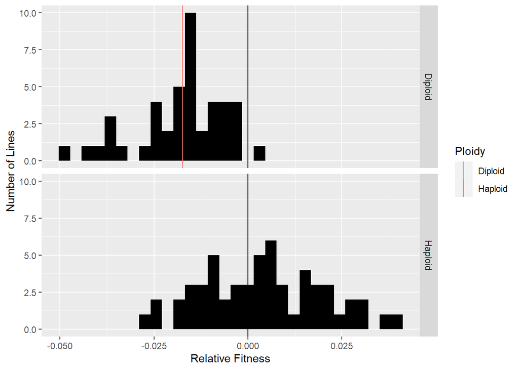

```r
trt2 %>% ggplot() +
  geom_histogram(aes(x=rel.fit), fill='black') +
  facet_grid(rows = vars(ploidy.x)) +
  geom_vline(data = data.frame(ploidy.x = c('Haploid', 'Diploid'),
                               mu = c(mu.hap, mu.dip)),
             aes(xintercept = mu, color = ploidy.x)) +
  geom_vline(xintercept = 0, color = 'black') +
  xlab("Relative Fitness") +
  ylab("Number of Lines") +
  guides(color = guide_legend(title = "Ploidy"))
```

lmer for hypothesis testing

```r
null <- lmer(slope ~ MA + ploidy + (1|date) + (1|treatment), data2)
summary(null)
```

```
## Linear mixed model fit by REML ['lmerMod']
## Formula: slope ~ MA + ploidy + (1 | date) + (1 | treatment)
##    Data: data2
##
## REML criterion at convergence: -4640.6
##
## Scaled residuals:
##     Min      1Q  Median      3Q     Max
## -3.2755 -0.5527  0.0712  0.6064  3.7382
##
## Random effects:
##  Groups    Name        Variance  Std.Dev.
##  treatment (Intercept) 0.0001440 0.01200
##  date      (Intercept) 0.0003444 0.01856
##  Residual              0.0022580 0.04752
## Number of obs: 1454, groups:  treatment, 106; date, 5
##
## Fixed effects:
##                Estimate Std. Error t value
## (Intercept)    0.144724   0.010866  13.318
## MAMA          -0.043950   0.006812  -6.452
## ploidyHaploid  0.011827   0.003950   2.995
##
## Correlation of Fixed Effects:
##             (Intr) MAMA
## MAMA        -0.578
## ploidyHapld -0.266  0.080
```

```r
full <- lmer(slope ~ MA*ploidy + (1|date) + (1|treatment), data2)
summary(full)
```

```
## Linear mixed model fit by REML ['lmerMod']
## Formula: slope ~ MA * ploidy + (1 | date) + (1 | treatment)
##    Data: data2
##
## REML criterion at convergence: -4635.7
##
## Scaled residuals:
##     Min      1Q  Median      3Q     Max
## -3.2812 -0.5482  0.0657  0.6035  3.7480
##
## Random effects:
##  Groups    Name        Variance  Std.Dev.
##  treatment (Intercept) 0.0001412 0.01188
##  date      (Intercept) 0.0003413 0.01847
##  Residual              0.0022581 0.04752
## Number of obs: 1454, groups:  treatment, 106; date, 5
##
## Fixed effects:
##                    Estimate Std. Error t value
## (Intercept)         0.13140    0.01492   8.806
## MAMA               -0.02977    0.01287  -2.313
## ploidyHaploid       0.02977    0.01442   2.065
## MAMA:ploidyHaploid -0.01936    0.01499  -1.292
##
## Correlation of Fixed Effects:
##             (Intr) MAMA   pldyHp
## MAMA        -0.806
## ploidyHapld -0.716  0.830
## MAMA:pldyHp  0.690 -0.851 -0.962
```

```r
mod <- anova(null, full)
```

```
## refitting model(s) with ML (instead of REML)
```

```r
mod
```

```
## Data: data2
## Models:
## null: slope ~ MA + ploidy + (1 | date) + (1 | treatment)
## full: slope ~ MA * ploidy + (1 | date) + (1 | treatment)
##      npar     AIC     BIC logLik deviance  Chisq Df Pr(>Chisq)
## null    6 -4653.8 -4622.1 2332.9  -4665.8
## full    7 -4653.5 -4616.5 2333.8  -4667.5 1.7555  1     0.1852
```

```r
full <- lmer(slope ~ ploidy + (1|date) + (1|treatment), data2[data2$MA == 'MA',])
summary(full)
```

```
## Linear mixed model fit by REML ['lmerMod']
## Formula: slope ~ ploidy + (1 | date) + (1 | treatment)
##    Data: data2[data2$MA == "MA", ]
##
## REML criterion at convergence: -3624.6
##
## Scaled residuals:
##     Min      1Q  Median      3Q     Max
## -3.2016 -0.5729  0.0399  0.4660  6.0906
##
## Random effects:
##  Groups    Name        Variance  Std.Dev.
##  treatment (Intercept) 7.397e-05 0.008601
##  date      (Intercept) 2.528e-04 0.015899
##  Residual              9.910e-04 0.031480
## Number of obs: 909, groups:  treatment, 102; date, 5
##
## Fixed effects:
##               Estimate Std. Error t value
## (Intercept)   0.108752   0.007534  14.434
## ploidyHaploid 0.007661   0.002829   2.709
##
## Correlation of Fixed Effects:
##             (Intr)
## ploidyHapld -0.240
```

```r
null <- lmer(slope ~ 1 + (1|date) + (1|treatment), data2[data2$MA == 'MA',])
mod <- anova(null, full)
```

```
## refitting model(s) with ML (instead of REML)
```

```r
mod
```

```
## Data: data2[data2$MA == "MA", ]
## Models:
## null: slope ~ 1 + (1 | date) + (1 | treatment)
## full: slope ~ ploidy + (1 | date) + (1 | treatment)
##      npar     AIC     BIC logLik deviance  Chisq Df Pr(>Chisq)
## null    4 -3627.5 -3608.2 1817.7  -3635.5
## full    5 -3632.6 -3608.5 1821.3  -3642.6 7.1408  1   0.007535 **
## ---
## Signif. codes:  0 '***' 0.001 '**' 0.01 '*' 0.05 '.' 0.1 ' ' 1
```

```r
full <- lmer(slope ~ ploidy + (1|date) + (1|treatment), data2[data2$MA == 'Ctrl',])
summary(full)
```

```
## Linear mixed model fit by REML ['lmerMod']
## Formula: slope ~ ploidy + (1 | date) + (1 | treatment)
##    Data: data2[data2$MA == "Ctrl", ]
##
## REML criterion at convergence: -1617.2
##
## Scaled residuals:
##     Min      1Q  Median      3Q     Max
## -3.6058 -0.6437  0.1827  0.7072  3.4504
##
## Random effects:
##  Groups    Name        Variance  Std.Dev.
##  date      (Intercept) 0.0021983 0.04689
##  treatment (Intercept) 0.0007524 0.02743
##  Residual              0.0027908 0.05283
## Number of obs: 545, groups:  date, 5; treatment, 4
##
## Fixed effects:
##               Estimate Std. Error t value
## (Intercept)    0.13345    0.03476   3.839
## ploidyHaploid  0.03345    0.03206   1.044
##
## Correlation of Fixed Effects:
##             (Intr)
## ploidyHapld -0.689
```

```r
null <- lmer(slope ~ 1 + (1|date) + (1|treatment), data2[data2$MA == 'Ctrl',])
mod <- anova(null, full)
```

```
## refitting model(s) with ML (instead of REML)
```

```r
mod
```

```
## Data: data2[data2$MA == "Ctrl", ]
## Models:
## null: slope ~ 1 + (1 | date) + (1 | treatment)
## full: slope ~ ploidy + (1 | date) + (1 | treatment)
##      npar     AIC     BIC logLik deviance  Chisq Df Pr(>Chisq)
## null    4 -1618.7 -1601.5 813.35  -1626.7
## full    5 -1618.1 -1596.6 814.07  -1628.1 1.4282  1     0.2321
```

Trying more lmer

```r
full <- lmer(slope ~ initial + (1|ploidy) + (1|MA) + (1|treatment) + (1|date), data2)
summary(full)
```

```
## Linear mixed model fit by REML ['lmerMod']
## Formula: slope ~ initial + (1 | ploidy) + (1 | MA) + (1 | treatment) +
##     (1 | date)
##    Data: data2
##
## REML criterion at convergence: -5070.6
##
## Scaled residuals:
##     Min      1Q  Median      3Q     Max
## -3.8284 -0.6062  0.0551  0.5260  4.3888
##
## Random effects:
##  Groups    Name        Variance  Std.Dev.
##  treatment (Intercept) 0.0002108 0.01452
##  date      (Intercept) 0.0001748 0.01322
##  MA        (Intercept) 0.0018146 0.04260
##  ploidy    (Intercept) 0.0001337 0.01156
##  Residual              0.0016458 0.04057
## Number of obs: 1454, groups:  treatment, 106; date, 5; MA, 2; ploidy, 2
##
## Fixed effects:
##              Estimate Std. Error t value
## (Intercept)  0.186150   0.032107   5.798
## initial     -0.196698   0.008715 -22.571
##
## Correlation of Fixed Effects:
##         (Intr)
## initial -0.080
```

```r
null <- lmer(slope ~ 1 + (1|ploidy) + (1|MA) + (1|treatment) + (1|date), data2)
anova(full, null)
```

```
## refitting model(s) with ML (instead of REML)
```

```
## Data: data2
## Models:
## null: slope ~ 1 + (1 | ploidy) + (1 | MA) + (1 | treatment) + (1 | date)
## full: slope ~ initial + (1 | ploidy) + (1 | MA) + (1 | treatment) + (1 | date)
##      npar     AIC     BIC logLik deviance  Chisq Df Pr(>Chisq)
## null    6 -4643.9 -4612.2 2327.9  -4655.9
## full    7 -5069.6 -5032.6 2541.8  -5083.6 427.76  1  < 2.2e-16 ***
## ---
## Signif. codes:  0 '***' 0.001 '**' 0.01 '*' 0.05 '.' 0.1 ' ' 1
```